# Cousera Machine Learning Project

Priyanka Roy

May 18, 2017

## Assignemnt Writeup

### Background

Using devices such as Jawbone Up, Nike FuelBand, and Fitbit it is now possible to collect a large amount of data about personal activity relatively inexpensively. These type of devices are part of the quantified self movement - a group of enthusiasts who take measurements about themselves regularly to improve their health, to find patterns in their behavior, or because they are tech geeks. One thing that people regularly do is quantify how much of a particular activity they do, but they rarely quantify how well they do it. In this project, your goal will be to use data from accelerometers on the belt, forearm, arm, and dumbell of 6 participants. They were asked to perform barbell lifts correctly and incorrectly in 5 different ways. More information is available from the website here: http://groupware.les.inf.puc-rio.br/har (see the section on the Weight Lifting Exercise Dataset).

### Data

The training data for this project are available here: https://d396qusza40orc.cloudfront.net/predmachlearn/pml-training.csv

The test data are available here: https://d396qusza40orc.cloudfront.net/predmachlearn/pml-testing.csv

The data for this project come from this source: http://groupware.les.inf.puc-rio.br/har. If you use the document you create for this class for any purpose please cite them as they have been very generous in allowing their data to be used for this kind of assignment.

### Goal

The goal of this project is to predict the manner in which they did the exercise. This is the “classe” variable in the training set.

### Load all the required libraries

```r
library(caret)
library(randomForest)
```

```r
library(rpart)
library(rpart.plot)
library(rattle)
```

### Loading the data sets

```r
Data_train <- read.csv("D:/Priyanka/Coursera/8.MachineLearning/pml-training.csv")
Data_test <- read.csv("D:/Priyanka/Coursera/8.MachineLearning/pml-testing.csv")
```

Partion the training into two parts

```r
inTrain <- createDataPartition(Data_train$classe, p=0.7, list = FALSE)
TrainSet <- Data_train[inTrain,]
TestSet <- Data_train[-inTrain,]
dim(TrainSet)
```

```
## [1] 13737   159
```

```r
dim(TestSet)
```

```
## [1] 5885  159
```

### Cleaning the data sets

Remove the varibles which have negligible variability

```r
nzv <- nearZeroVar(TrainSet)
TrainSet <- TrainSet[,-nzv]
TestSet <- TestSet[,-nzv]
dim(TrainSet)
```

```
## [1] 13737   108
```

```r
dim(TestSet)
```

```
## [1] 5885  108
```

Remove the variables which has NA for more than 95% of the observations

```r
AllNA <- sapply(TrainSet, function(x) mean(is.na(x))) > 0.95
TrainSet <- TrainSet[, AllNA == FALSE]
TestSet <- TestSet[,AllNA == FALSE]
dim(TrainSet)
```

```
## [1] 13737    58
```

```r
dim(TestSet)
```

```
## [1] 5885   58
```

Remove the varibles which behaves as an identifier only

```r
TrainSet <- TrainSet[,-(1:4)]
TestSet <- TestSet[,-(1:4)]
dim(TrainSet)
```

```
## [1] 13737    54
```

```r
dim(TestSet)
```

```
## [1] 5885   54
```

### Modelling starts

#### Random Forest

```r
ControlRF <- trainControl(method = "cv", number = 3)
m_rf <- train(classe ~., data = TrainSet, method = "rf", trControl = ControlRF)
m_rf$finalModel
```

```
##
## Call:
##  randomForest(x = x, y = y, mtry = param$mtry)
##                Type of random forest: classification
##                      Number of trees: 500
## No. of variables tried at each split: 27
##
##         OOB estimate of  error rate: 0.25%
## Confusion matrix:
##      A    B    C    D    E  class.error
## A 3904    1    0    0    1 0.0005120328
## B    3 2651    2    2    0 0.0026335591
## C    0    4 2391    1    0 0.0020868114
## D    0    0   12 2239    1 0.0057726465
## E    0    0    0    7 2518 0.0027722772
```

```r
pred_rf <- predict(m_rf, TestSet)
conf_mat_rf <- confusionMatrix(pred_rf, TestSet$classe)
conf_mat_rf
```

```
## Confusion Matrix and Statistics
##
##           Reference
## Prediction    A    B    C    D    E
##          A 1674    3    0    0    0
##          B    0 1136    1    0    0
##          C    0    0 1025    1    0
##          D    0    0    0  963    3
##          E    0    0    0    0 1079
##
## Overall Statistics
##
##                Accuracy : 0.9986
##                  95% CI : (0.9973, 0.9994)
##     No Information Rate : 0.2845
##     P-Value [Acc > NIR] : < 2.2e-16
##
##                   Kappa : 0.9983
##  Mcnemar's Test P-Value : NA
##
## Statistics by Class:
##
##                      Class: A Class: B Class: C Class: D Class: E
## Sensitivity            1.0000   0.9974   0.9990   0.9990   0.9972
## Specificity            0.9993   0.9998   0.9998   0.9994   1.0000
## Pos Pred Value         0.9982   0.9991   0.9990   0.9969   1.0000
## Neg Pred Value         1.0000   0.9994   0.9998   0.9998   0.9994
## Prevalence             0.2845   0.1935   0.1743   0.1638   0.1839
## Detection Rate         0.2845   0.1930   0.1742   0.1636   0.1833
## Detection Prevalence   0.2850   0.1932   0.1743   0.1641   0.1833
## Balanced Accuracy      0.9996   0.9986   0.9994   0.9992   0.9986
```

#### Decision Tree

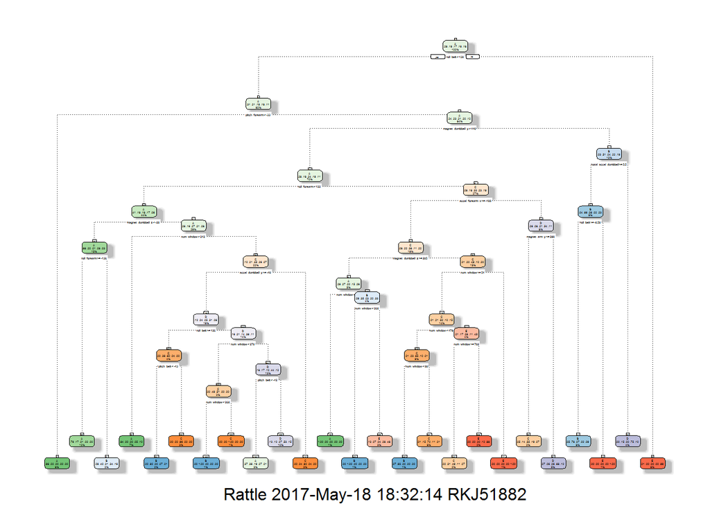

```r
m_dt <- rpart(classe ~., data = TrainSet, method = "class")
fancyRpartPlot(m_dt)
```

```r
pred_dt <- predict(m_dt, TestSet, type ="class")
conf_mat_dt <- confusionMatrix(pred_dt, TestSet$classe)
conf_mat_dt
```

```
## Confusion Matrix and Statistics
##
##           Reference
## Prediction    A    B    C    D    E
##          A 1494  193   36   63   53
##          B   52  649   33   70   55
##          C   15  135  875   99   23
##          D   85  144   78  675  149
##          E   28   18    4   57  802
##
## Overall Statistics
##
##                Accuracy : 0.7638
##                  95% CI : (0.7527, 0.7746)
##     No Information Rate : 0.2845
##     P-Value [Acc > NIR] : < 2.2e-16
##
##                   Kappa : 0.7006
##  Mcnemar's Test P-Value : < 2.2e-16
##
## Statistics by Class:
##
##                      Class: A Class: B Class: C Class: D Class: E
## Sensitivity            0.8925   0.5698   0.8528   0.7002   0.7412
## Specificity            0.9181   0.9558   0.9440   0.9073   0.9777
## Pos Pred Value         0.8124   0.7555   0.7629   0.5968   0.8823
## Neg Pred Value         0.9555   0.9025   0.9681   0.9392   0.9437
## Prevalence             0.2845   0.1935   0.1743   0.1638   0.1839
## Detection Rate         0.2539   0.1103   0.1487   0.1147   0.1363
## Detection Prevalence   0.3125   0.1460   0.1949   0.1922   0.1545
## Balanced Accuracy      0.9053   0.7628   0.8984   0.8038   0.8595
```

#### Gradient Boosting Modelling

```r
ControlGBM <- trainControl(method = "repeatedcv", number = 5, repeats = 2)
m_gbm <- train(classe ~., data = TrainSet, method = "gbm", trControl = ControlGBM)
m_gbm$finalModel
```

```
## A gradient boosted model with multinomial loss function.
## 150 iterations were performed.
## There were 53 predictors of which 41 had non-zero influence.
```

```r
pred_gbm <- predict(m_gbm, TestSet)
conf_mat_gbm <- confusionMatrix(pred_gbm, TestSet$classe)
conf_mat_gbm
```

```
## Confusion Matrix and Statistics
##
##           Reference
## Prediction    A    B    C    D    E
##          A 1665   11    0    0    0
##          B    9 1116    8    6    3
##          C    0   10 1013    4    3
##          D    0    2    5  953   10
##          E    0    0    0    1 1066
##
## Overall Statistics
##
##                Accuracy : 0.9878
##                  95% CI : (0.9846, 0.9904)
##     No Information Rate : 0.2845
##     P-Value [Acc > NIR] : < 2.2e-16
##
##                   Kappa : 0.9845
##  Mcnemar's Test P-Value : NA
##
## Statistics by Class:
##
##                      Class: A Class: B Class: C Class: D Class: E
## Sensitivity            0.9946   0.9798   0.9873   0.9886   0.9852
## Specificity            0.9974   0.9945   0.9965   0.9965   0.9998
## Pos Pred Value         0.9934   0.9772   0.9835   0.9825   0.9991
## Neg Pred Value         0.9979   0.9952   0.9973   0.9978   0.9967
## Prevalence             0.2845   0.1935   0.1743   0.1638   0.1839
## Detection Rate         0.2829   0.1896   0.1721   0.1619   0.1811
## Detection Prevalence   0.2848   0.1941   0.1750   0.1648   0.1813
## Balanced Accuracy      0.9960   0.9872   0.9919   0.9926   0.9925
```

### Model Accuracy Comparison and Predicting using Test Data set

Hence randome forest comes out to be the most efficient model.

Using randome forest model, predicting the test data.

```r
Pred_test <- predict(m_rf, Data_test)
Pred_test
```

```
##  [1] B A B A A E D B A A B C B A E E A B B B
## Levels: A B C D E
```